# Lesson 16: Describing Categorical Data; Proportions; Sampling Distribtion of a Sample Proportion

Homework

- Word Document
- PDF Document

## Solutions

**Please note that the steps show rounded numbers, but that the final answers to the problems are calculated without rounding.**

Problem

Part

Solution

1

-

A pie chart is used for categorical data. Each slice represents a part of a whole. A histogram, on the other hand, is used for quantitative data. It is a visual representation of the spread of a set of data.

2

-

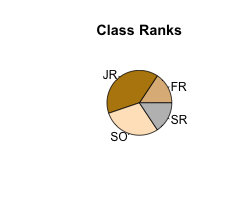

3

-

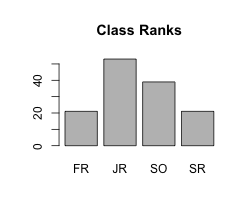

4

-

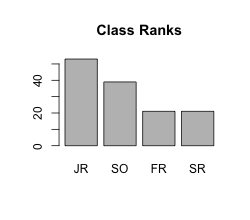

5

-

The sample proportion $\hat{p}$ will be approximately normal when $n$ is large. How do we know if $n$ is large? We will conclude that $n$ is large when $np \geq 10$ and $n(1 - p) \geq 10$

6

-

n = 100

7

-

The sample proportion $\hat{p}$ will be approximately normal when:  
$np \geq 10$ and $n(1 - p) \geq 10$  
$1000(0.528) = 528 \geq 10$ and $1000(1-0.528) = 472 \geq 10$  
Since both conditions are true, we conclude that $n$ is sufficiently large so that $\hat{p}$ will be approximately distributed.

8

-

The sampling distribution of $\hat{p}$ is approximately normal with mean $p = 0.528$ and $\text{standard deviation of } 0.016$.

9

-

$z = -1.774$

10

-

$P(Z=-1.774) = 0.038$

11

-

The sample proportion $\hat{p}$ will be approximately normal when:  
$np \geq 10$ and $n(1 - p) \geq 10$  
$4040(0.5) = 2020 \geq 10$ and $4040(1-0.5) = 2020 \geq 10$  
Since both conditions are true, we conclude that $n$ is sufficiently large so that $\hat{p}$ will be approximately distributed.

12

-

The sampling distribution of $\hat{p}$ is approximately normal with mean $p = 0.5$ and $\text{standard deviation of } 0.008$.

13

-

$P(Z=0.881 \text{ or } Z=-0.881) = 0.378$